# Homework 5 Responses

Zeyi Han, Shubhi Sharma, Margaret Swift

2/24/2020

## Exercise 1

Find the MLE, the likelihood profile, and the 95% CI for waiting times that are exponentially distributed:

$$L(\mathbf{y}; \lambda) = \prod_{i=1}^n \lambda e^{-y_i \lambda}$$

Log likelihood of exponential distribution is:

$$\log L(\mathbf{y}; \lambda) = n\log\lambda - n\lambda\bar{y}$$
Solving the partial derivative of the log likelihood with respect to $\lambda$, we get the MLE of exponential distribution:
$$\hat{\lambda} = \frac{1}{\bar{y}}$$
The likelihood ratio is:
$$\log R = \log \lambda_0 + \log \bar{y} -\bar{y} \lambda_0 + 1$$

Here is a simulated data set and its MLE, likelihood profile and 95% CI.

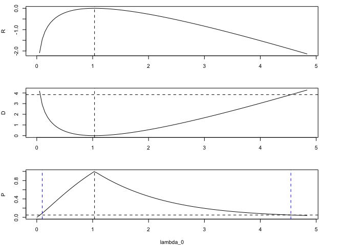

## Exercise 2

Use Fisher Information to find the standard error of the mean of a normal sampling distribution.

$Solution:$ First, we find the likelihood function and only take the proportional pieces w.r.t. $\mu$:
$$L(\mathbf{y};\mu, \sigma^2)
= \prod_{i=1}^n \frac{1}{\sqrt{2\pi\sigma^2}} \exp\left\{-\frac12 \frac{(y_i-\mu)^2}{\sigma^2}\right\}
\propto\exp\left\{-\frac12 \frac{\sum (y_i-\mu)^2}{\sigma^2}\right\}$$
Next, we take the log of the likelihood, and find the second derivative with respect to $\mu$.
$$\log L(\mathbf{y};\mu, \sigma^2) =
-\frac{1}{2\sigma^2} \sum y_i^2-2y_i\mu + \mu^2$$

$$\frac{d}{d\mu}\left[\log L(\mathbf{y};\mu, \sigma^2)\right] =
\sum \frac{y_i}{\sigma^2} - \frac{\mu}{\sigma^2}$$

$$\frac{d^2}{d\mu^2}\left[\log L(\mathbf{y};\mu, \sigma^2)\right] =
- \frac{n}{\sigma^2}$$

$$I = -\frac{d^2}{d\mu^2}\log L(\mu)\bigg\rvert_{\hat{\mu}} = \frac{n}{\sigma^2}$$

Now that we have the Fisher’s Information, we can use it to estimate the standard error of the mean:
$$se_{\hat{\mu}} = \frac{1}{\sqrt{I}} = \frac{\sigma}{\sqrt n}$$

The standard error of the mean will decrease with our sample size $n$ as $n\to\infty$.

## Exercise 3

Estimate the standard error for the exponential model using Fisher Information.

$Solution:$ First, we find the likelihood function and only take the proportional pieces w.r.t. $\lambda$:

$$L(\mathbf{y};\lambda)
= \prod_{i=1}^n \lambda e^{-\lambda y_i} = \lambda^ne^{-\lambda\sum y_i}$$
Next, we take the log of the likelihood, and find the second derivative w.r.t. $\lambda$.
$$\log L(\mathbf{y};\lambda)
= n\log\lambda - n\lambda\bar{y}$$
We take the first derivative, and stop to find the MLE for $\lambda$:
$$\frac{d}{d\lambda}\left[\log L(\mathbf{y};\lambda) \right]
= \frac{n}{\lambda} - n\bar{y}
\implies
\hat{\lambda} = \frac{1}{\bar{y}}$$
And continue to find the second derivative for Fisher’s:
$$\frac{d^2}{d\mu^2}\left[\log L(\mathbf{y};\lambda) \right]
= -\frac{n}{\lambda^2}$$
$$I = -\frac{d^2}{d\mu^2}\log L(\lambda)\bigg\rvert_{\hat{\lambda}} =\frac{n}{\lambda^2}\bigg\rvert_{\hat{\lambda}}
= n\bar{y}^2$$

Now that we have the Fisher’s Information, we can use it to estimate the standard error:
$$se_{\hat{\lambda}}
= \frac{1}{\sqrt{I}}
=\sqrt{\frac{1}{n\bar{y}^2}}$$

The standard error will still decrease as our sample size increases to $\infty$, for $y_i>1$.

## Exercise 4

For the cone example, I used the likelihood $Poi(y_i | \beta x_i)$. Combine this likelihood with the prior $gamma(\beta | a, b)$ and answer the following:

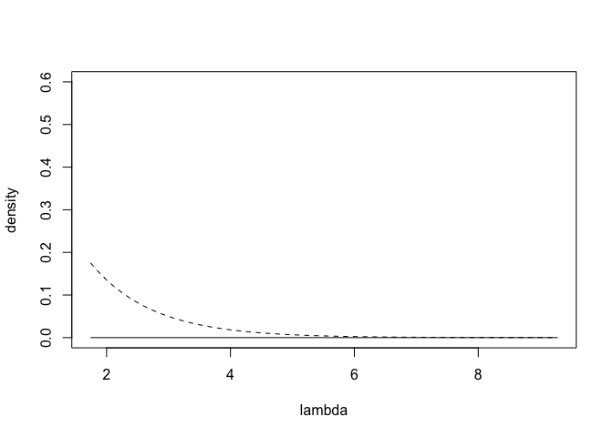

1. What is the posterior density for $\beta$?

The posterior distribution for $\beta$ is a new gamma distribution: $gamma(\beta|n\bar{y} + a -1, n\bar{x^2} + b)$

2. For simulated data sets of $n = 5$, how do the standard errors and credible intervals for this model compare with Fisher information?

The standard errors for the posterior distribution for beta in the cone example, the standard error and credible intervals are 0.01 and 0.02, 0.04.

3. The form of the Bayesian standard error and the standard error from Fisher Information look different. Can you explain why numerically they are similar? [Hint: think about sample size $n$].

## Group exercise

I want to get a feel for the uncertainty on the estimate of the variance for a Gaussian model for continuous observations $y$. I would like to compare different methods.

1. Find the MLE for the variance. If you have time to kill, derive the Fisher information and the SE. Compare the estimates for different sample sizes.

To find the MLE, we have an approximate Gaussian density:

$$(2\pi\sigma^2)^{-n/2}\exp\left\{ -\frac12 \frac{(\sum y_i-\mu)^2}{\sigma^2}\right\}
\propto
(\sigma^2)^{-n/2}\exp\left\{ -\frac12 \frac{(\sum y_i-\mu)^2}{\sigma^2}\right\}$$
took the log, found the first derivative, and set it equal to zero:

$$\frac{d}{d\sigma^2}\left[-\frac{n}{2}\log(\sigma^2) -\frac12 (\sum y_i-\mu)^2(\sigma^2)^{-1}\right]
= -\frac{n}{2\sigma^2} + \frac{1}{2(\sigma^2)^2}\left(\sum y_i-\mu\right)^2 = 0$$

$$\frac{n}{2\sigma^2} = \frac{1}{2(\sigma^2)^2}\left(\sum y_i-\mu\right)^2$$
$$\sigma^2_{MLE} = \frac{1}{n}\left(\sum y_i-\mu\right)^2$$

The MLEs we found for variance for $n=1, 10, 1000$ are, respectively, 0.0839, 0.2676, and 1.0723. As you can see, the variance comes closer and closer to the true variance, 1, as the sample size increases.

## Group exercise

MLE for variance

Let $y_i \sim N(0, \sigma^2)$ and $\mathbb{E}[x] = 0$

$$\begin{aligned}
p(Y) &= \left( \frac{1}{2\pi \sigma^2} \right)^{-n/2} e\left(\frac{-1}{2\sigma^2}\sum_i(y_i)^2 \right)\\
\text{Let } \sigma^2 &= \theta\\
\log L(\theta \mid Y) &= \frac{-n}{2}\left(\log \theta + \frac{1}{\theta} \frac{\sum y_i^2}{n}\right)\\
\frac{\partial}{\partial \theta}&= \frac{-n}{2}\left( \theta - \frac{1}{\theta^2} \frac{\sum y_i^2}{n}\right)\\
\text{Setting first } & \text{derivarite to 0, }\\
0 &= \frac{-n}{2}\left( \theta - \frac{1}{\theta^2} \frac{\sum y_i^2}{n}\right)\\
\hat{\theta} &= \frac{\sum y_i^2}{n}
\end{aligned}$$

Bootstrap to get MLE estimate for variance

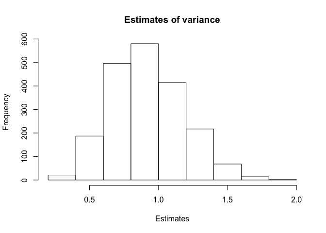

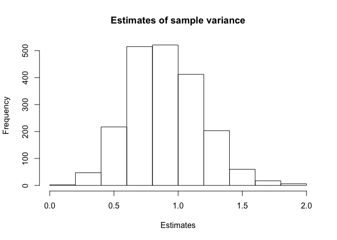

Bayesian version Writing the variance as precision
$$\begin{aligned}
p(y \mid \theta ) &= \left( \frac{\theta}{2\pi} \right)^{-n/2} e\left(\frac{-\theta}{2}\sum_i(y_i)^2 \right)\\
p(\theta) &\propto \theta^{\alpha -1} e^{-\theta \beta}\\
p(\theta \mid y) &\propto \theta^{\alpha + n/2 - 1} e^{\beta + 0.5 \sum_i (y_i)^2}\\
&\sim Ga(a + n/2, \beta + 0.5 \sum_i(y_i)^2)\\
&\sim Ga(a_n, b_n)\\
\end{aligned}$$

Sample from the posterior

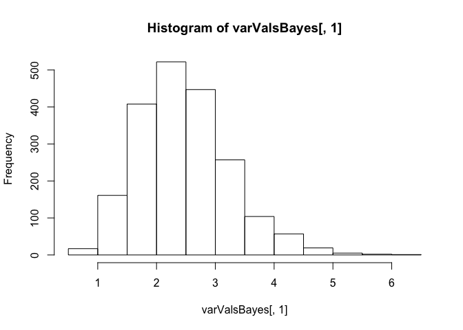

## Appendix

```r
#----------------------------------------------------------------------------
# LOADING
knitr::opts_chunk$set(echo=FALSE, eval=TRUE, cache=TRUE)
pacman::p_load(ggplot2)
source('../clarkfunctions2020.R')
# Rcpp::sourceCpp('../cppFns.cpp')
# any libraries and data here

#----------------------------------------------------------------------------
# FUNCTIONS
# put functions here


#----------------------------------------------------------------------------
## EXERCISE 1

n    <- 1000
y    <- rexp(n)                                   #simulated waiting times
ybar <- mean(y)
ycap <- 1/ybar
rseq <- seq(0,5,length=100)*ybar
R <- log(rseq) + log(ybar) - ybar * rseq + 1   #normed likelihood

par(mfrow=c(3,1), mar=c(4,4,1,4))
plot(rseq,R, type = "l", xlab = "")
abline(v=ycap,lty=2)
D  <- -2*R                # Deviance
plot(rseq,D,type='l', xlab='')
abline(v=ycap,lty=2)
abline(h=3.84,lty=2)      # value of D at P = 0.05

P <- 1 - pchisq(D,1)      #P value
plot(rseq, P, type='l', xlab='lambda_0')
abline(v=ycap,lty=2)
abline(h=.05, lty=2)

#find the 95% CI:
CI <- range(rseq[P > .05])
abline(v=CI, lty=2, col = "blue")
#----------------------------------------------------------------------------
## EXERCISE 4
# (b)
n    <- 5
y    <- rpois(n,4.7)                                   #simulated cone counts
ybar <- mean(y)
rseq <- seq(.3,1.6,length=100)*ybar
x <- runif(n,0,30)
a <- b <- 1
plot(rseq,dgamma(rseq, a, b), type='l', lty=2, ylim=c(0,.6),
     xlab = 'lambda', ylab = 'density')

A <- sum(y) + a - 1
B <- n*(mean(x)^2) + b

lines(rseq,dgamma(rseq, A, B), type='l')
ci <- qgamma(c(.025,.975), A, B)
segments(ci[1], 0, ci[1], dgamma(ci[1],A,B))
segments(ci[2], 0, ci[2], dgamma(ci[2],A,B))

selamb <- sqrt(A/(B^2))
# fisher information
Ise <- sqrt(A/(n*(B^2)))

#----------------------------------------------------------------------------
## GROUP EXERCISE

MLE <- function(n) {
  mu <- 0;
  y <- rnorm(n, mu)
  return(1/n * sum((y-mu)^2))
}
set.seed(123)
y <- rnorm(20, 0, 1)
Y <- mean(y)
nlo <- length(y)

nboot <- 2000
varVals <- matrix(0, nboot, 1)

for(b in 1:nboot){

  bindex <- sample(y, nlo, replace = T)
  Y <- mean(bindex)
  varVals[b,1] <- sum(bindex^2)/nlo

}

hist(varVals[,1], main = paste0("Estimates of variance"), xlab = "Estimates")


#sample variance

varValsSample <- matrix(0, nboot, 1)

for(b in 1:nboot){

    bindex <- sample(y, nlo, replace = T)
  Y <- mean(bindex)
  div <- 1/(nlo - 1)
  varValsSample[b,1] <- sum((bindex - Y)^2)*div
}

hist(varValsSample[,1], main = paste0("Estimates of sample variance"), xlab = "Estimates")
#this does better

set.seed(123)
y <- rnorm(20, 0, 1)
n <- length(y)
#hyperparameters
a <- b <- 0.01

#posterior parameters
an <- a + n/2
bn <- b + 0.5*sum(y)^2

nsamp <- 2000
varValsBayes <- matrix(0, nsamp,1 )

varValsBayes[, 1] <- rgamma(nsamp, an, bn)

hist(varValsBayes[,1])
```